# Exam 1

## Exam 1

#### Question

1. (2.5 puntos) La población de parásitos que infecta un árbol, en miles, evoluciona diariamente siguiendo la sucesión recursiva $x_1=2$ y $x_{n+1}=1-(2+x_n)^{-1}$ $\forall n\in\mathbb{N}$. Demostrar que la sucesión converge y calcular su límite.

#### Solution

   El término recurrente de la sucesión puede escribirse de la siguiente manera

   $$x_{n+1}=1-(2+x_n)^{-1} = \frac{1+x_n}{2+x_n}\ \forall n\in\mathbb{N}.$$

   Veamos primero que la sucesión está acotada inferiormente por $0$ por inducción. $x_1=2>0$, y suponiendo $x_n>0$ se tiene que $x_{n+1} = \frac{1+x_n}{2+x_n} >0$ $\forall n\in\mathbb{N}$.

   $$\begin{gathered}
   x_{n-1}>x_n \Leftrightarrow 2+x_{n-1} > 2+x_n \Leftrightarrow (2+x_{n-1})^{-1} < (2+x_n)^{-1} \\
   \Leftrightarrow 1-(2+x_{n-1})^{-1} > 1-(2+x_n)^{-1} \Leftrightarrow x_{n}>x_{n+1}\ \forall n\in\mathbb{N}.
   \end{gathered}$$

   Así pues, como la sucesión es monótona decreciente y está acotada inferiormente, según el [teorema de la convergencia monótona](https://aprendeconalf.es/analisis-manual/sucesiones.html#thm-convergencia-monotona), la sucesión converge.

   Para calcular el límite aprovechamos la recurrencia,

   $$x = \lim_{n\to\infty}x_n = \lim_{n\to\infty} \frac{1+x_{n-1}}{2+x_{n-1}} =\frac{1+\lim_{n\to\infty}x_{n-1}}{2+\lim_{n\to\infty}x_{n-1}} = \frac{1+x}{2+x},$$

   y resolviendo la ecuación se tiene

   $$x = \frac{1+x}{2+x} \Leftrightarrow x(2+x) = 1+x \Leftrightarrow x^2+x-1=0 \Leftrightarrow x = \frac{-1\pm \sqrt{5}}{2}.$$

   Como hemos visto que la sucesión está acotada inferiormente por $0$, podemos descartar la solución negativa, de manera que, $\lim_{n\to\infty}x_n = \frac{-1+ \sqrt{5}}{2}$.

#### Question

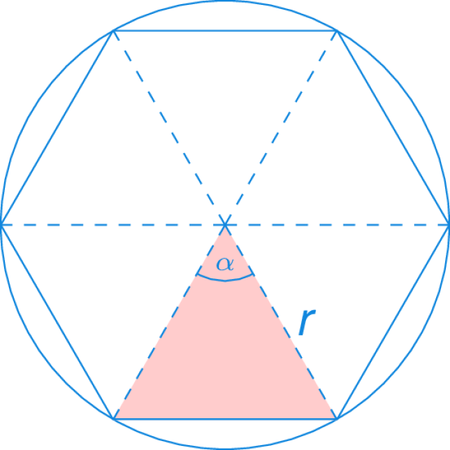

   1. Dar el término general de la sucesión $(a_n)_{n=3}^\infty$ que expresa el área del polígono en función del número de lados $n$.
   2. Calcular el límite de la sucesión.

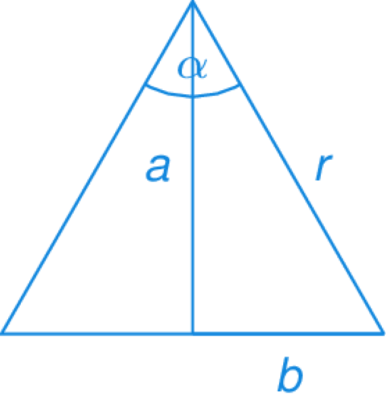

#### Question

3. (1 punto) Sabiendo que $\operatorname{sen}(x)$ y $x$ son infinitesimos equivalentes en $x=0$, demostrar que también lo son $\operatorname{tg}(x)$ y $x$.

#### Question

4. (2.5 puntos) Determinar el dominio y las asíntotas de la función.

   $$f(x)=\sqrt{\frac{x^3}{4x-1}}.$$

#### Question

5. (2 puntos) Dado el conjunto $A=\{x\in\mathbb{R} : \frac{x^2-1}{x-2}\leq 0\}$, calcular, si existe, el supremo, ínfimo, máximo y mínimo. ¿Es un conjunto cerrado o abierto?